# EPI-clone Figure 2

Michael Scherer & Lars Velten

13/03/2024

This vignette shows some applications of EPI-clone in combination with the DNA methylation readout provided by scTAM-seq.

## Differentiation uMAP (Figure 2a)

We simply load the data and visualize the integrated uMAP that shows three differentiation trajectories.

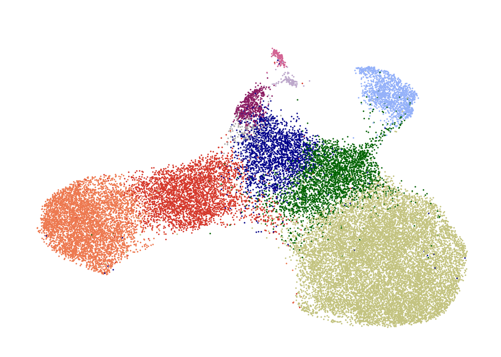

```r
seurat_obj <- readRDS(url('https://figshare.com/ndownloader/files/42479346'))
DimPlot(seurat_obj, group.by = "CellType",reduction="umap") + ggtitle("") + NoAxes() + NoLegend() + scale_color_manual(values = color_map)
```

## Transcriptomic uMAP

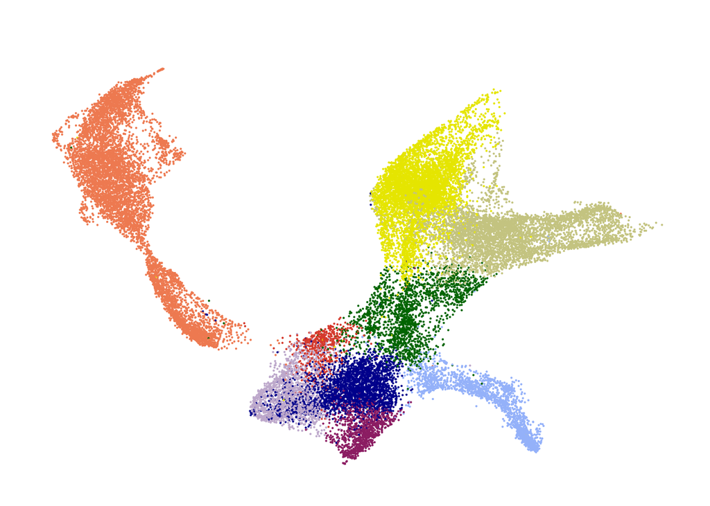

```r
seurat_rna <- readRDS(url("https://figshare.com/ndownloader/files/42587815"))
DimPlot(seurat_rna, group.by = "CellType") + ggtitle("") + NoAxes() + NoLegend() + scale_color_manual(values = color_map)
```

## Compare information content on cell types

To compare the information content encoded in both modalities, we trained RandomForest classifiers and then compared the information content with the entropy of all cell types.

```r
control <- trainControl(method='repeatedcv',
                        number=10,
                        repeats=1)
counts_dnam <- GetAssayData(seurat_obj,
                            slot='counts',
                            assay='DNAm')
pred_dat <- data.frame(CellType=as.factor(seurat_obj$CellType),
                       t(as.matrix(counts_dnam)))
rf_dnam <- randomForest(CellType~.,
                 data=pred_dat)
counts_rna <- GetAssayData(seurat_rna,
                           slot='data',
                           assay='RNA')
counts_rna <- counts_rna[VariableFeatures(seurat_rna), ]
pred_dat_rna <- data.frame(CellType=as.factor(seurat_rna$CellType),
                           t(as.matrix(counts_rna)))
rf_rna <- randomForest(CellType~.,
                        data=pred_dat_rna)
unex_dnam <- entropy(seurat_obj$CellType)
ex_dnam <- mutinformation(seurat_obj$CellType,
                          rf_dnam$predicted)
unex_rna <- entropy(seurat_rna$CellType)
ex_rna <- mutinformation(seurat_rna$CellType,
                         rf_rna$predicted)

to_plot <- data.frame(Modality = rep(c("RNA","DNAm"), each =2),
                  Type = rep(c("Unexplained", "Full"), 3),
                  Information = natstobits(c(unex_rna, ex_rna, unex_dnam, ex_dnam)))

ggplot(to_plot, aes(x = Modality, y = Information, fill = Type)) + geom_col(position = position_identity()) +
  scale_fill_manual(values = c("Unexplained" = "darkgrey","Full" = "darkred"), name = "") +
  plot_theme + ylab("Information on Cell Types (bits)") + xlab("Modality")
```

[output not shown]

## Cell type annotation with bulk profiles

To annotate the different clusters we identified, we leverage information from bulk data. Using this information, we can compute a relative methylation score for a subset of amplicons in each of the cells.

```r
panel_file <- '../infos/panel_info_dropout_pwm.tsv'
counts <- as.matrix(GetAssayData(seurat_obj,
                       'DNAm',
                       slot='counts'))
```

```r
plot_hsc <- plot_type_methylation(seurat_obj,
                                  t(counts),
                                  type='HSC_high',
                                  panel = panel_file)+
  plot_theme_title+ggtitle('HSC high')
```

```
## [1] "Using 82 amplicons"
```

```r
plot_mpp <- plot_type_methylation(seurat_obj,
                                  t(counts),
                                  type='MPP_high',
                                  panel = panel_file)+
  plot_theme_title+ggtitle('MPP3/4 high')
```

```
## [1] "Using 58 amplicons"
```

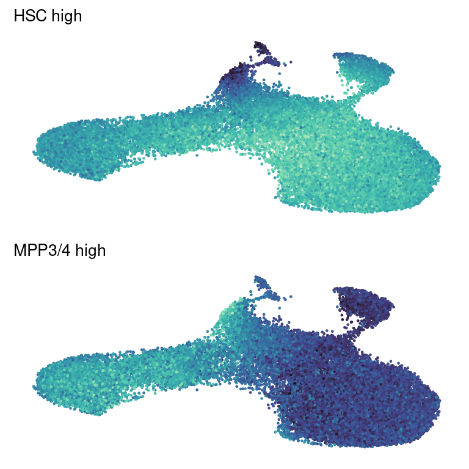

```r
grid.arrange(plot_hsc,
             plot_mpp,
             nrow=2)
```

## Surface protein expression per cell type

In a first step, we only use data, where antibody staining was performed and remove cells from plotting that do not express any surface antibodies or where there is another potential issue with the antibody staining (unusually high expression of all surface markers).

```r
seurat_ab <- subset(seurat_obj,
                    ProcessingBatch%in%c('LK_LSK_stained', 'LARRY_mouse3', 'LARRY_mouse4'))
```

We use CLR normalization, which is typically used for normalization of surface marker expression data.

```
## Normalizing across features
```

For plotting purposes, we only use the surface markers, SCA-1, cKIT, CD48, CD150, CD135 and CD201, which are commonly used for sorting different HSPC (HSC and MPP) populations.

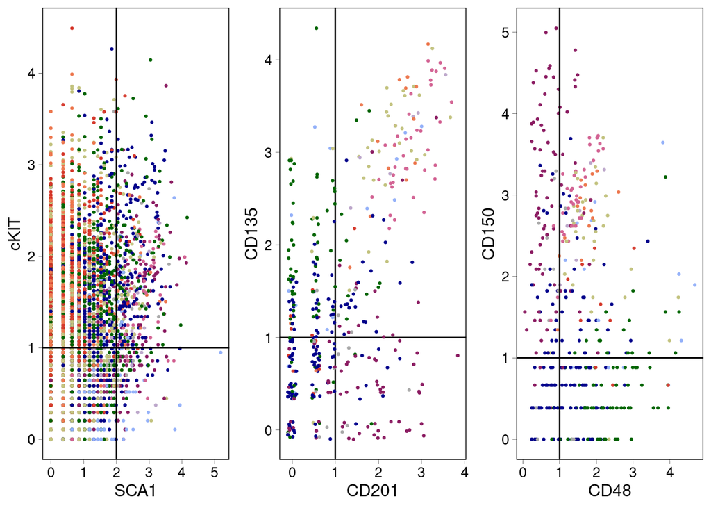

## Visualize TFBS methylation

By using the methylation at CpGs located in the vicinity of a TFBS, we can compute a relative methylation state for each cell. This shows where the HSCs/MPPs are located in the UMAP and how TFBS become de-methylated with differentiation.

```r
plot_gata2 <- plot_tfbs_methylation(seurat_obj,
                      t(counts),
                      panel=panel_file,
                      'Gata2_ChIP')+plot_theme_title+ggtitle('Gata2')
```

```
## [1] "Using 21 amplicons"
```

```r
plot_spi <- plot_tfbs_methylation(seurat_obj,
                                   t(counts),
                                   panel=panel_file,
                                   'Spi1')+plot_theme_title+ggtitle('Spi1')
```

```
## [1] "Using 52 amplicons"
```

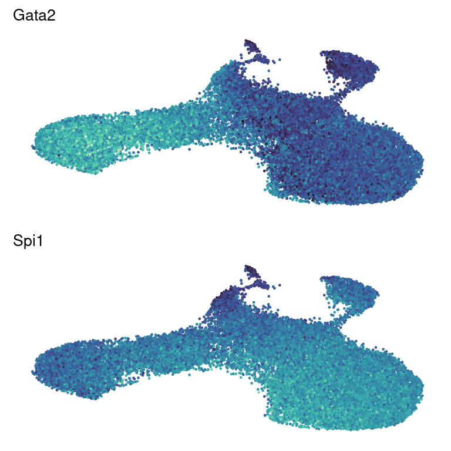

```r
grid.arrange(plot_gata2,
             plot_spi,
             nrow=2)
```

## TFBS enrichment

To extend upon the analysis above, we investigate many important hematopoietic TFs with respect to their DNA methylation state in our data. Specifically, we define CpG that are specifically unmethylated in a cell type and scan for enrichment of TFBS.

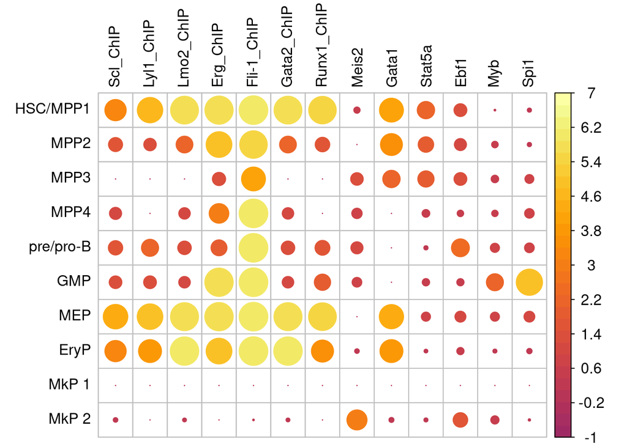

```r
Idents(seurat_obj) <- 'CellType'
panel <- read.table(panel_file,
                    sep='\t')
markers_hsc <- differential_test(seurat_obj,
                            ident.1 = 'HSC/MPP1')
enrichments_hsc <- run_marker_enrichment(markers_hsc,
                                          panel,
                                          fc.cut = 0.5)
markers_mkp1 <- differential_test(seurat_obj,
                                  ident.1 = 'MkP 1')
enrichments_mkp1 <- run_marker_enrichment(markers_mkp1,
                                          panel,
                                          fc.cut = 0.5)
markers_mkp2 <- differential_test(seurat_obj,
                                  ident.1 = 'MkP 2')
enrichments_mkp2 <- run_marker_enrichment(markers_mkp2,
                                          panel,
                                          fc.cut = 0.5)
markers_mpp2 <- differential_test(seurat_obj,
                                  ident.1 = 'MPP2')
enrichments_mpp2 <- run_marker_enrichment(markers_mpp2,
                                          panel,
                                          fc.cut = 1)
markers_mpp3 <- differential_test(seurat_obj,
                            ident.1 = 'MPP3')
enrichments_mpp3 <- run_marker_enrichment(markers_mpp3,
                                          panel,
                                          fc.cut = 1)
markers_mpp4 <- differential_test(seurat_obj,
                           ident.1 = 'MPP4')
enrichments_mpp4 <- run_marker_enrichment(markers_mpp4,
                                         panel,
                                         fc.cut = 1)
markers_preb <- differential_test(seurat_obj,
                            ident.1 = 'pre/pro-B')
enrichments_preb <- run_marker_enrichment(markers_preb,
                                          panel,
                                          fc.cut = 1)
markers_myo <- differential_test(seurat_obj,
                                    ident.1 = 'GMP')
enrichments_myo <- run_marker_enrichment(markers_myo,
                                            panel,
                                            fc.cut = 1)
markers_meg <- differential_test(seurat_obj,
                              ident.1 = 'MEP')
enrichments_meg <- run_marker_enrichment(markers_meg,
                                            panel,
                                            fc.cut = 1)
markers_ery <- differential_test(seurat_obj,
                           ident.1 = 'EryP')
enrichments_ery <- run_marker_enrichment(markers_ery,
                                         panel,
                                         fc.cut = 1)
all_tfs <- unique(c(enrichments_hsc$Negative$TFBS$x,
                    #enrichments_mkp1$Negative$TFBS$x,
                    enrichments_mkp2$Negative$TFBS$x,
                    enrichments_mpp2$Negative$TFBS$x,
                    enrichments_mpp3$Negative$TFBS$x,
                    enrichments_mpp4$Negative$TFBS$x,
                    enrichments_preb$Negative$TFBS$x,
                    enrichments_myo$Negative$TFBS$x,
                    enrichments_meg$Negative$TFBS$x,
                    enrichments_ery$Negative$TFBS$x))
to_plot <- matrix(1, nrow=length(all_tfs), ncol=10)
row.names(to_plot) <- all_tfs
colnames(to_plot) <- c('HSC/MPP1',
                       'MPP2',
                       'MPP3',
                       'MPP4',
                       'pre/pro-B',
                       'GMP',
                       'MEP',
                       'EryP',
                       'MkP 1',
                       'MkP 2')
to_plot[enrichments_hsc$Negative$TFBS$x, 'HSC/MPP1'] <- enrichments_hsc$Negative$TFBS$enrichment
to_plot[, 'MkP 1'] <- 1
to_plot[enrichments_mkp2$Negative$TFBS$x, 'MkP 2'] <- enrichments_mkp2$Negative$TFBS$enrichment
to_plot[enrichments_mpp2$Negative$TFBS$x, 'MPP2'] <- enrichments_mpp2$Negative$TFBS$enrichment
to_plot[enrichments_mpp3$Negative$TFBS$x, 'MPP3'] <- enrichments_mpp3$Negative$TFBS$enrichment
to_plot[enrichments_mpp4$Negative$TFBS$x, 'MPP4'] <- enrichments_mpp4$Negative$TFBS$enrichment
to_plot[enrichments_preb$Negative$TFBS$x, 'pre/pro-B'] <- enrichments_preb$Negative$TFBS$enrichment
to_plot[enrichments_myo$Negative$TFBS$x, 'GMP'] <- enrichments_myo$Negative$TFBS$enrichment
to_plot[enrichments_meg$Negative$TFBS$x, 'MEP'] <- enrichments_meg$Negative$TFBS$enrichment
to_plot[enrichments_ery$Negative$TFBS$x, 'EryP'] <- enrichments_ery$Negative$TFBS$enrichment

to_plot <- to_plot[c(row.names(to_plot)[grepl('ChIP', row.names(to_plot))],
                     row.names(to_plot)[!grepl('ChIP', row.names(to_plot))]),]
rem_tfs <- apply(to_plot, 1, function(x)all(x>0.01))
to_plot <- to_plot[!rem_tfs, ]
to_plot <- to_plot[c('Scl_ChIP',
                     'Lyl1_ChIP',
                     'Lmo2_ChIP',
                     'Erg_ChIP',
                     'Fli-1_ChIP',
                     'Gata2_ChIP',
                     'Runx1_ChIP',
                     'Meis2',
                     'Gata1',
                     'Stat5a',
                     'Ebf1',
                     'Myb',
                     'Spi1'), ]
corrplot(-log10(t(to_plot+1e-6)),
         is.corr = FALSE,
         tl.col = 'black',
         col=inferno(50),
         col.lim=c(-1, 7),
         tl.cex = 1,
         cl.cex = 1)
```

## Plot HSC score and overall methylation

To better characterize all cell populations, we computed the average methylation value in HSC-specific CpGs as well as the average methylation state across all CpGs in our panel.

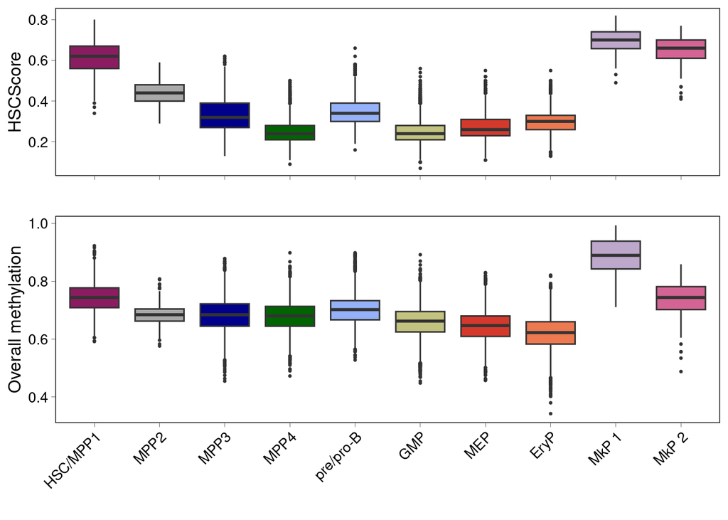

```r
sel_amplicons <- row.names(subset(panel, subset=Type=='HSC_high'))
hsc_score <- colSums(counts[intersect(sel_amplicons, rownames(counts)), ]>0)/length(sel_amplicons)
meth <- colSums(counts>0)/nrow(counts)
to_plot <- data.frame(Cluster=seurat_obj$CellType, HSCScore=hsc_score, Methylation=meth)
to_plot$Cluster <- factor(to_plot$Cluster, levels=names(color_map))
plot_hsc <- ggplot(to_plot, aes(x=Cluster, y=HSCScore, fill=Cluster))+geom_boxplot(outlier.size = .5)+
  plot_theme+theme(axis.text.x = element_blank())+scale_fill_manual(values = color_map)+
  xlab('')
plot_meth <- ggplot(to_plot, aes(x=Cluster, y=Methylation, fill=Cluster))+geom_boxplot(outlier.size = .5)+
  plot_theme+theme(axis.text.x = element_text(angle=45, hjust=1))+scale_fill_manual(values = color_map)+
  xlab('')+ylab('Overall methylation')
grid.arrange(plot_hsc, plot_meth, layout_matrix=as.matrix(c(1,1,2,2,2)))
```

## Identify MkP 1 and MkP 2 in RNA

Since we can associate a particular LARRY barcode in the two modalities, we can investigate whether we can detect the two populations MkP 1 and MkP 2 in the RNA UMAP.

As a first step, we search for the DNAm LARRY barcodes in the RNA modality.

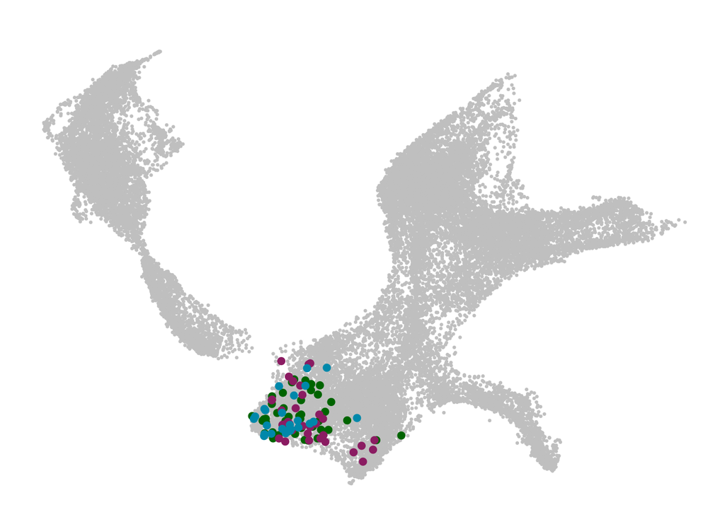

```r
hsc_barcodes <- unique(na.omit(seurat_obj$LARRY[seurat_obj$CellType%in%'HSC/MPP1']))
mkp1_barcodes <- unique(na.omit(seurat_obj$LARRY[seurat_obj$CellType%in%'MkP 1']))
mkp2_barcodes <- unique(na.omit(seurat_obj$LARRY[seurat_obj$CellType%in%'MkP 2']))

seurat_rna$HSCCousin <- factor(ifelse(seurat_rna$LARRY%in%hsc_barcodes, 'Cousin', 'Other'), levels=c('Cousin', 'Other'))
seurat_rna$MkP1Cousin <- factor(ifelse(seurat_rna$LARRY%in%mkp1_barcodes, 'Cousin', 'Other'), levels=c('Cousin', 'Other'))
seurat_rna$MkP2Cousin <- ifelse(seurat_rna$LARRY%in%mkp2_barcodes, 'Cousin', 'Other')
seurat_rna$Cousins <- ifelse(seurat_rna$LARRY%in%mkp1_barcodes&seurat_rna$LARRY%in%hsc_barcodes,
                             'HSC&MkP 1',
                             ifelse(seurat_rna$LARRY%in%mkp1_barcodes, 'MkP 1',
                                    ifelse(seurat_rna$LARRY%in%hsc_barcodes, 'HSC', 'Other')))
to_plot <- as.data.frame(seurat_rna[['umap_harmony']]@cell.embeddings)
to_plot <- data.frame(to_plot, Cousins=factor(seurat_rna$Cousins, levels=rev(c('MkP 1', 'HSC', 'HSC&MkP 1', 'Other'))))
to_plot$Cousins[!(seurat_rna$CellType%in%c('HSC/MPP1', 'MkP'))] <- 'Other'
to_plot <- to_plot[order(to_plot$Cousins), ]
ggplot(to_plot, aes(x=umapharmony_1, y=umapharmony_2, color=Cousins, size=Cousins))+geom_point(stroke=.5)+
plot_theme_title+guides(color = guide_legend(override.aes = list(size = 3.5), title='Cousins'))+
  scale_color_manual(values=c('HSC&MkP 1'='darkgreen',
                                    'MkP 1'='#0088aa',
                                    'HSC'='maroon4',
                                    'Other'='gray75'))+scale_size_manual(values=c('HSC&MkP 1'=2,
                                    'MkP 1'=2,
                                    'HSC'=2,
                                    'Other'=.5))+NoAxes()+ggtitle("")+NoGrid()
```

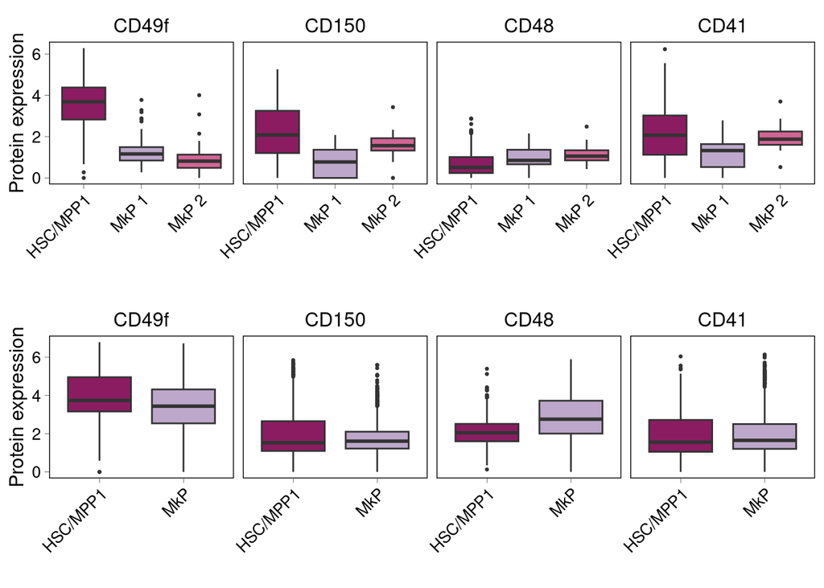

```r
seurat_ab <- subset(seurat_obj,
                    ProcessingBatch%in%c('LK_LSK_stained', 'LARRY_mouse3', 'LARRY_mouse4'))
adt_data <- t(as.matrix(GetAssayData(seurat_ab,
                                     assay='AB')))
all_zeros <- apply(adt_data, 1, function(x)all(is.na(x), na.rm=TRUE))
adt_data[all_zeros, ] <- 0
all_zeros <- all_zeros|apply(adt_data, 1, function(x)all(x>1, na.rm = TRUE))
seurat_ab <- seurat_ab[, !all_zeros]
adt_data <- GetAssayData(seurat_ab,
                         assay='AB')
adt_data[is.na(adt_data)] <- 0
adt_dnam <- data.frame(CellType=seurat_obj[[]][colnames(adt_data), 'CellType'], t(adt_data[c("CD49f-raw", "CD150-raw", "CD48-raw", "CD41-raw"), ]))
adt_dnam <- subset(adt_dnam, CellType%in%c('HSC/MPP1', 'MkP 1', 'MkP 2'))
colnames(adt_dnam)[2:5] <- c('CD49f', 'CD150', 'CD48', 'CD41')
seurat_rna_ab <- subset(seurat_rna, ProcessingBatch%in%c('LARRY_mouse1', 'LARRY_mouse2', 'LARRY_mouse3', 'LARRY_mouse4', 'LK_LSK_stained'))
adt_rna <- data.frame(CellType=seurat_rna[[]][Cells(seurat_rna_ab), 'CellType'], t(GetAssayData(seurat_rna_ab, slot='data', assay='AB')[c("CD49f-totalseqb", "CD150-totalseqb", "CD48-totalseqb", "CD41-totalseqb"), ]))
adt_rna <- subset(adt_rna, CellType%in%c('HSC/MPP1', 'MkP'))
colnames(adt_rna)[2:5] <- c('CD49f', 'CD150', 'CD48', 'CD41')
to_plot <- reshape2::melt(adt_dnam, id='CellType')
plot_dnam <- ggplot(to_plot, aes(x=CellType, y=value, fill=CellType))+geom_boxplot(outlier.size = .5)+plot_theme+facet_wrap(variable~., nrow=1)+scale_fill_manual(values=color_map)+ylab('Protein expression')+theme(axis.text.x = element_text(angle=45, hjust=1))+xlab('')
to_plot <- reshape2::melt(adt_rna, id='CellType')
plot_rna <- ggplot(to_plot, aes(x=CellType, y=value, fill=CellType))+geom_boxplot(outlier.size = .5)+plot_theme+facet_wrap(variable~., nrow=1)+scale_fill_manual(values=c('HSC/MPP1'='maroon4', 'HSC1'='maroon2', 'HSC2'='maroon1', 'HSC3'='maroon3', color_map))+ylab('Protein expression')+theme(axis.text.x = element_text(angle=45, hjust=1))+xlab('')
grid.arrange(plot_dnam, plot_rna, nrow=2)
```